# Lemurs

## Set Up

```r
library(tidyverse)
library(skimr)
library(patchwork)
library(cowplot)
library(ggridges)
```

## Import

```r
# use tidytuesdayR package to read 'taxonomy' data only
## parsing failure with lemurs data
taxonomy <- tidytuesdayR::tt_load(2021, week = 35, download_files = "taxonomy") %>% .$taxonomy
```

```
--- Compiling #TidyTuesday Information for 2021-08-24 ----
--- There are 2 files available ---
--- Starting Download ---
```

```
--- Download complete ---
```

```r
# read lemurs file sorting out parsing failure
lemurs <- readr::read_csv('https://raw.githubusercontent.com/rfordatascience/tidytuesday/master/data/2021/2021-08-24/lemur_data.csv',
                          col_types = cols(
                            age_of_living_y = col_double()))
```

## Tidying and Transformation

### Join datasets

Join both datasets so can use ‘common names’ rather than ‘taxon’ codes. First attempt resulted in missing values so I explored and corrected the differences between the two sets of data and re_joined them.

```r
# need to explore taxonomy dataset and look for error ?taxon codes that don't match
anti_join(lemurs, taxonomy) %>%
  distinct(taxon) %>% .$taxon
```

```
[1] "CMED"
```

```r
# taxon = "CMED" in one set "CMEAD" in the other --> NA when left join
# recode so these match
taxonomy$taxon <-
  taxonomy$taxon %>%
  fct_recode(CMED = "CMEAD")

# join both datasets so can use common names rather than 'taxon' codes
lemurs <- lemurs %>%
  left_join(taxonomy) %>%
  select(common_name, everything())
```

### Single row for each individual lemur

Grouped together data for each individual lemur so each lemur is represented by a single row. Multiple rows exist due to weight data for different ages. Can use original dataset to look at weight data and this new data_frame to look at individual lemurs.

There are 2 different hybrid species both coded as ‘hybrid’ so they are joined together when grouping by ‘common’ name. This distorts the data so I chose to exclude hybrid species from my analysis.

```r
lemurs_distinct <- distinct(lemurs, dlc_id, .keep_all = TRUE) %>%
  filter(common_name != "hybrid")
```

### Choose top species

Create new object - a data-frame containing data for the *n* commonest species.

```r
n <- 5

top_species <- lemurs_distinct %>%
  group_by(common_name) %>%
  count() %>%
  arrange(desc(n)) %>%
  head(n) %>%
  pull(common_name)

top_species<- lemurs_distinct %>%
  filter(common_name %in% top_species)
```

## Exploration

### Descriptive statistics

```r
skim(lemurs)
```

```
-- Data Summary ------------------------
                           Values
Name                       lemurs
Number of rows             82609
Number of columns          56
_______________________
Column type frequency:
  character                21
  Date                     8
  numeric                  27
________________________
Group variables            None

-- Variable type: character --------------------------------------------------------
# A tibble: 21 x 8
```

[output cut: 107 more lines]

```r
descriptive <- lemurs %>%
  select(c(birth_month, age_at_death_y, litter_size, n_known_offspring)) %>%
  psych::describe() %>%
  select(-(c(vars)))

descriptive
```

|  | n | mean | sd | median | trimmed | mad | min | max | range | skew | kurtosis | se |
| --- | --- | --- | --- | --- | --- | --- | --- | --- | --- | --- | --- | --- |
| birth_month | 82601 | 5.58 | 2.70 | 5.00 | 5.38 | 2.97 | 1 | 12.00 | 11.00 | 0.58 | -0.23 | 0.01 |
| age_at_death_y | 45240 | 17.51 | 8.43 | 17.36 | 17.41 | 9.19 | 0 | 39.39 | 39.39 | 0.10 | -0.68 | 0.04 |
| litter_size | 64440 | 1.65 | 0.82 | 1.00 | 1.53 | 0.00 | 1 | 4.00 | 3.00 | 1.03 | 0.20 | 0.00 |
| n_known_offspring | 46046 | 5.59 | 4.75 | 4.00 | 4.77 | 2.97 | 1 | 36.00 | 35.00 | 1.70 | 3.55 | 0.02 |

## Visualisation

### Distribution of species

#### Overall

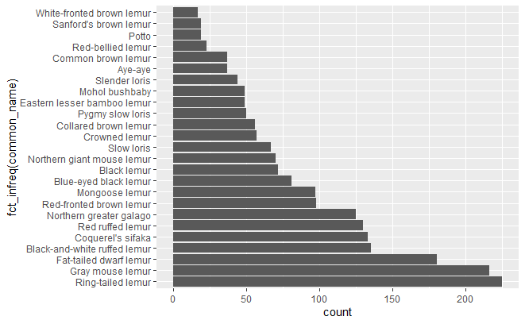

```r
lemurs_distinct %>%
  ggplot(aes(x = fct_infreq(common_name)))+
  geom_bar()+
  coord_flip()
```

#### Top n species

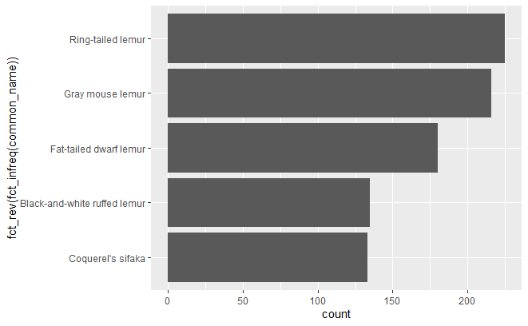

```r
top_species %>%
  ggplot(aes(x = fct_rev(fct_infreq(common_name))))+
  geom_bar()+
  coord_flip()
```

#### Birth Month

Explore distribution of months of birth.

Birth month is a discrete variable so convert numbers (integers) to month abbreviation and plot as a bar chart. Will need to produce an ordered factor for birth month and exclude missing values. Also exclude any estimated dob.

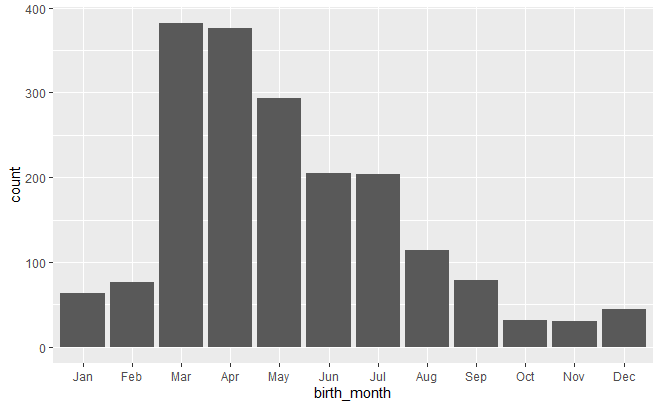

```r
lemurs_distinct %>%
  drop_na(birth_month) %>%
  filter(is.na(estimated_dob)) %>%
  mutate(birth_month = month.abb[birth_month],
         birth_month = factor(birth_month,
                              levels = month.abb,
                              ordered = TRUE)) %>%
  ggplot(aes(x = birth_month))+
  geom_bar()
```

#### Age at death

Filter for those with known dob and known dod. This is to ensure accurate data. These are all captive born so data only represents captive born lemurs

```r
life_exp <- top_species %>%
  filter(!is.na(dob) & !is.na(dod) & is.na(estimated_dob))

life_exp[life_exp$birth_type != "CB",]
```

| common_name | taxon | dlc_id | hybrid | sex | name | current_resident | stud_book | dob | birth_month | estimated_dob | birth_type | birth_institution | litter_size | expected_gestation | estimated_concep | concep_month | dam_id | dam_name | dam_taxon | dam_dob | dam_age_at_concep_y | sire_id | sire_name | sire_taxon | sire_dob | sire_age_at_concep_y | dod | age_at_death_y | age_of_living_y | … |
| --- | --- | --- | --- | --- | --- | --- | --- | --- | --- | --- | --- | --- | --- | --- | --- | --- | --- | --- | --- | --- | --- | --- | --- | --- | --- | --- | --- | --- | --- | --- |

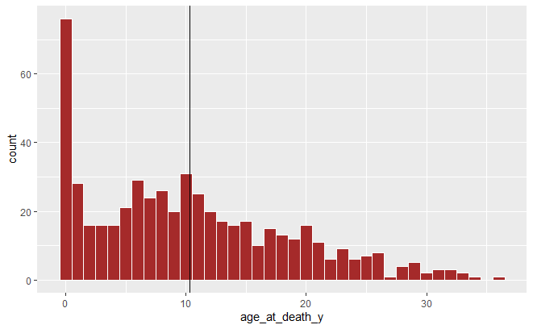

```r
life_exp %>%
  ggplot(aes(x = age_at_death_y))+
  geom_histogram(binwidth = 1, colour = "white", fill = "brown")+
  geom_vline(xintercept = mean(life_exp$age_at_death_y, na.rm = TRUE))
```

Multi-modal distribution - is this due to different mortality rates at different ages or is there a difference between species?

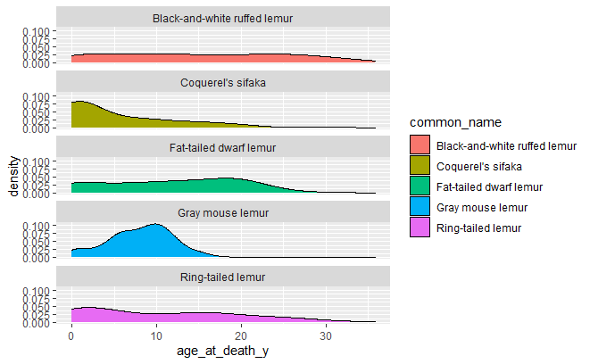

```r
life_exp %>%
  ggplot(aes(x = age_at_death_y))+
  geom_density(aes(fill = common_name))+
  facet_wrap(~ common_name, ncol = 1)
```

Produce a plot of descriptive statistics for each of commonest species of lemur

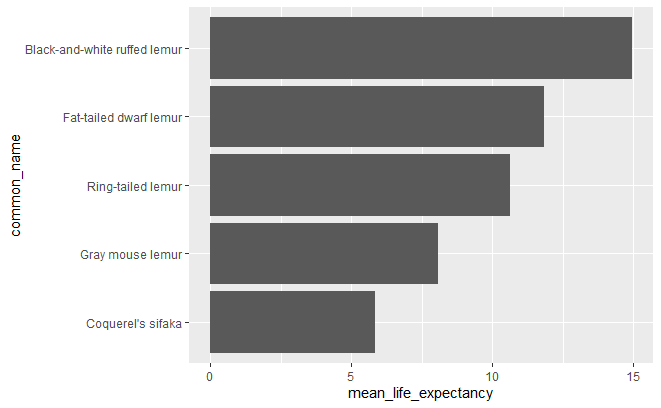

```r
life_exp %>%
  filter(!is.na(dob) & !is.na(dod) & birth_type == "CB"
         & is.na(estimated_dob)) %>%
  group_by(common_name) %>%
  summarise(mean_life_expectancy = mean (age_at_death_y, na.rm = TRUE)) %>%
  mutate (common_name = fct_reorder(common_name, mean_life_expectancy)) %>%
  ggplot()+
  geom_col(aes(x = common_name, y = mean_life_expectancy))+
  coord_flip()
```

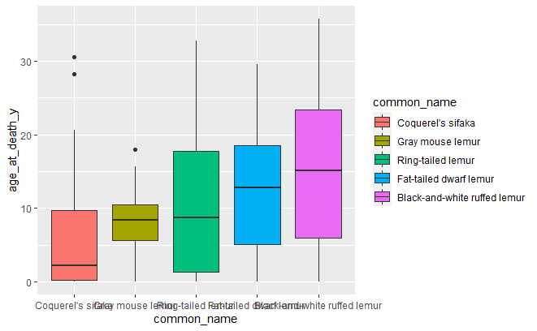

```r
life_exp %>%
  mutate(common_name = fct_reorder(common_name, age_at_death_y)) %>%
  ggplot()+
  geom_boxplot(aes(fill = common_name, x = common_name, y = age_at_death_y))
```

## Final Plots

Add colour

Tidy up labels etc.

Group together using patchwork package

Annotate as needed

### Generic settings

```r
lemur_pal <- c("#ccb79d", "#6e5337", "#687277", "#949992", "#c69d60")

mean_age <- mean(life_exp$age_at_death_y) %>% round(2)

life_exp <- life_exp %>%
  mutate(common_name = fct_reorder(common_name, age_at_death_y))
```

### Individual plots

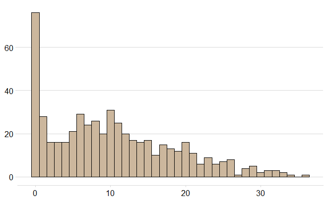

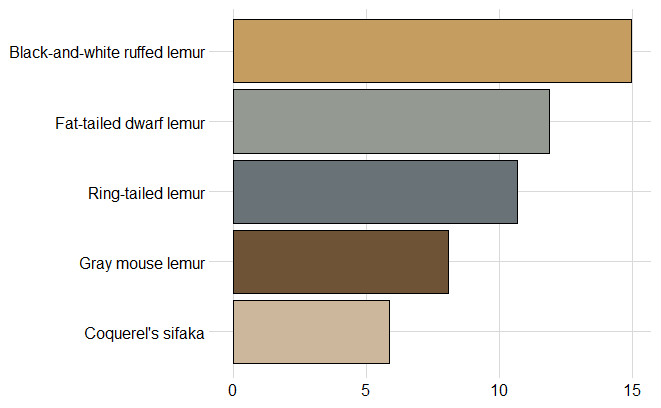

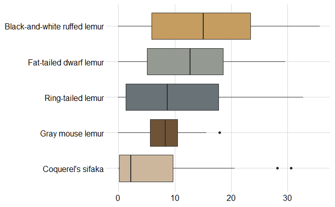

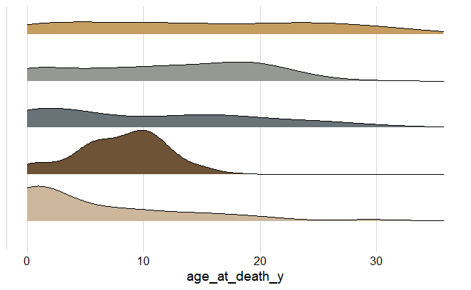